# Metro Valencia

Ernesto Martínez

```r
gtfs <- read_gtfs("../data/gtfs_data/transit_metrovalencia.zip")
print(names(gtfs))
```

```
## [1] "agency"         "calendar"       "calendar_dates" "trips"
## [5] "stop_times"     "stops"          "routes"         "shapes"
## [9] "."
```

```r
print(gtfs$.$dates_services)
```

```
## # A tibble: 558 × 2
##    date       service_id
##    <date>     <chr>
##  1 2022-02-05 100
##  2 2022-02-06 200
##  3 2022-02-12 100
##  4 2022-02-13 200
##  5 2022-02-19 100
##  6 2022-02-20 200
##  7 2022-02-26 100
##  8 2022-02-27 200
##  9 2022-03-05 100
## 10 2022-03-06 200
## # ℹ 548 more rows
```

```r
gtfs$calendar$service_id <- as.factor(gtfs$calendar$service_id)
gtfs$trips$service_id <- as.factor(gtfs$trips$service_id)
```

```r
# get the most frequent service_id

gtfs$trips %>%
  group_by(service_id) %>%
  summarise(frequency = n()) %>%
  arrange(desc(frequency))
```

```
## # A tibble: 8 × 2
##   service_id frequency
##   <fct>          <int>
## 1 2562            1817
## 2 2518            1815
## 3 2516            1718
## 4 2554            1718
## 5 2522            1369
## 6 2502            1154
## 7 100             1082
## 8 200              976
```

```r
# get the frequenct for routes

gtfs$trips %>%
  group_by(route_id) %>%
  summarise(frequency = n()) %>%
  arrange(desc(frequency))
```

```
## # A tibble: 143 × 2
##    route_id    frequency
##    <chr>           <int>
##  1 V10-190-197       398
##  2 V10-197-190       398
##  3 V5-123-182        369
##  4 V7-123-107        358
##  5 V3-64-182         354
##  6 V5-182-123        353
##  7 V3-182-64         349
##  8 V7-107-123        342
##  9 V10-190-194       335
## 10 V10-194-190       335
## # ℹ 133 more rows
```

```r
# merge the routes with the trips

yes <- gtfs$trips %>%
  inner_join(gtfs$routes, by = "route_id")

yes %>%
  filter(route_id == "V8-126-123")
```

```
## # A tibble: 266 × 11
##    route_id service_id trip_id trip_headsign shape_id agency_id route_short_name
##    <chr>    <fct>      <chr>   <chr>         <chr>    <chr>     <chr>
##  1 V8-126-… 2502       4118798 Marítim       59       1         8
##  2 V8-126-… 2502       4118802 Marítim       59       1         8
##  3 V8-126-… 2502       4118807 Marítim       59       1         8
##  4 V8-126-… 2502       4118812 Marítim       59       1         8
##  5 V8-126-… 2502       4118817 Marítim       59       1         8
##  6 V8-126-… 2502       4118821 Marítim       59       1         8
##  7 V8-126-… 2502       4118826 Marítim       59       1         8
##  8 V8-126-… 2502       4118831 Marítim       59       1         8
##  9 V8-126-… 2502       4118835 Marítim       59       1         8
## 10 V8-126-… 2502       4118840 Marítim       59       1         8
## # ℹ 256 more rows
## # ℹ 4 more variables: route_long_name <chr>, route_type <int>,
## #   route_color <chr>, route_text_color <chr>
```

```r
yes %>%
  group_by(route_color) %>%
  summarise(frequency = n()) %>%
  arrange(desc(frequency)) %>%
  print(n = 1000)
```

```
## # A tibble: 11 × 2
##    route_color frequency
##    <chr>           <int>
##  1 F28D01           2476
##  2 B7DD79           2173
##  3 8884BF           1320
##  4 FEC601           1046
##  5 DD052C           1022
##  6 82CEE6            936
##  7 CE142B            845
##  8 014A99            749
##  9 B8804F            632
## 10 E60096            252
## 11 008F71            198
```

Para conseguir cuántas paradas hay por cada ruta y cuáles son

```r
trips_stops_details <- gtfs$trips %>%
  left_join(gtfs$routes, by = "route_id") %>%
  left_join(gtfs$stop_times, by = "trip_id") %>%
  left_join(gtfs$stops, by = "stop_id")


stops_by_route <- trips_stops_details %>%
  select(route_id, route_long_name, trip_id, stop_id, stop_sequence, stop_name, stop_lat, stop_lon) %>%
  arrange(route_long_name, trip_id, stop_sequence)
```

```r
unique_stops_by_route <- stops_by_route %>%
  distinct(route_id, stop_id, .keep_all = TRUE)

stops_for_a_specific_route <- unique_stops_by_route %>%
  filter(route_id == "3RFA")
```

```r
stops_for_a_specific_route
```

```
## # A tibble: 27 × 8
##    route_id route_long_name     trip_id stop_id stop_sequence stop_name stop_lat
##    <chr>    <chr>               <chr>   <chr>           <int> <chr>        <dbl>
##  1 3RFA     3 - Aeroport a Raf… 2966185 18                  0 Av. del …     39.5
##  2 3RFA     3 - Aeroport a Raf… 2966185 17                  1 Àngel Gu…     39.5
##  3 3RFA     3 - Aeroport a Raf… 2966185 16                  2 Xàtiva        39.5
##  4 3RFA     3 - Aeroport a Raf… 2966185 15                  3 Colón         39.5
##  5 3RFA     3 - Aeroport a Raf… 2966185 14                  4 Alameda       39.5
##  6 3RFA     3 - Aeroport a Raf… 2966185 13                  5 Facultat…     39.5
##  7 3RFA     3 - Aeroport a Raf… 2966185 12                  6 Benimacl…     39.5
##  8 3RFA     3 - Aeroport a Raf… 2966185 11                  7 Machado       39.5
##  9 3RFA     3 - Aeroport a Raf… 2966185 10                  8 Alboraia…     39.5
## 10 3RFA     3 - Aeroport a Raf… 2966185 9                   9 Alboraia…     39.5
## # ℹ 17 more rows
## # ℹ 1 more variable: stop_lon <dbl>
```

Dividir las paradas según el momento del día

```r
gtfs$stop_times <- gtfs$stop_times %>%
  mutate(time_of_day = case_when(
    hour(arrival_time) >= 6 & hour(arrival_time) < 9 ~ "Morning",
    hour(arrival_time) >= 9 & hour(arrival_time) < 12 ~ "Mid morning",
    hour(arrival_time) >= 12 & hour(arrival_time) < 15 ~ "Midday",
    hour(arrival_time) >= 15 & hour(arrival_time) < 18 ~ "Evening",
    hour(arrival_time) >= 18 & hour(arrival_time) < 21 ~ "Afternoon",
    hour(arrival_time) >= 21 | hour(arrival_time) < 6 ~ "Night",
    TRUE ~ "Otro"
  ))


gtfs$stop_times
```

```
## # A tibble: 208,261 × 7
##    trip_id arrival_time departure_time stop_id stop_sequence timepoint
##    <chr>   <time>       <time>         <chr>           <int>     <int>
##  1 2965738 04:44        04:44          86                  0         1
##  2 2965738 04:45        04:45          87                  1         1
##  3 2965738 04:46        04:46          88                  2         1
##  4 2965738 04:47        04:47          89                  3         1
##  5 2965738 04:49        04:49          90                  4         1
##  6 2965738 04:51        04:51          12                  5         1
##  7 2965738 04:53        04:53          91                  6         1
##  8 2965738 04:57        04:57          92                  7         1
##  9 2965738 05:00        05:00          93                  8         1
## 10 2965738 05:02        05:02          94                  9         1
## # ℹ 208,251 more rows
## # ℹ 1 more variable: time_of_day <chr>
```

```r
gtfs$stop_times %>%
  inner_join(gtfs$stops, by = "stop_id") %>%
  inner_join(gtfs$trips, by = "trip_id") %>%
  filter(stop_id == "89")
```

```
## # A tibble: 2,791 × 15
##    trip_id arrival_time departure_time stop_id stop_sequence timepoint
##    <chr>   <time>       <time>         <chr>           <int>     <int>
##  1 2965738 04:47        04:47          89                  3         1
##  2 2965739 05:08        05:08          89                  6         1
##  3 2965740 05:19        05:19          89                  3         1
##  4 2965741 05:22        05:22          89                  3         1
##  5 2965742 05:28        05:28          89                  6         1
##  6 2965743 05:48        05:48          89                  6         1
##  7 2965745 05:59        05:59          89                  3         1
##  8 2965746 06:08        06:08          89                  6         1
##  9 2965747 06:28        06:28          89                  6         1
## 10 2965749 06:43        06:43          89                 10         1
## # ℹ 2,781 more rows
## # ℹ 9 more variables: time_of_day <chr>, stop_name <chr>, stop_lat <dbl>,
## #   stop_lon <dbl>, zone_id <chr>, route_id <chr>, service_id <fct>,
## #   trip_headsign <chr>, shape_id <chr>
```

```r
gtfs$calendar_dates <- gtfs$calendar_dates %>%
  mutate(weekday = wday(gtfs$calendar_dates$date, week_start = 1))

gtfs$calendar_dates %>%
  arrange(date)
```

```
## # A tibble: 150 × 4
##    service_id date       exception_type weekday
##    <chr>      <date>              <int>   <dbl>
##  1 2562       2024-02-09              1       5
##  2 2522       2024-02-10              1       6
##  3 2502       2024-02-11              1       7
##  4 2516       2024-02-12              1       1
##  5 2554       2024-02-13              1       2
##  6 2554       2024-02-14              1       3
##  7 2554       2024-02-15              1       4
##  8 2518       2024-02-16              1       5
##  9 2522       2024-02-17              1       6
## 10 2502       2024-02-18              1       7
## # ℹ 140 more rows
```

Calcular la frecuencia de cada service_id en base al día de la semana con una tabla de contingencia

```r
contingency_table <- xtabs(~ service_id + weekday, data = gtfs$calendar_dates)

contingency_table
```

```
##           weekday
## service_id  1  2  3  4  5  6  7
##       2502  2  0  3  1  0  0 44
##       2516 15 14 15 15  0  0  0
##       2518  0  1  0  0 16  0  0
##       2522  0  0  0  0  0 20  0
##       2554  0  1  1  1  0  0  0
##       2562  0  0  0  0  1  0  0
```

```r
# Calcula los totales por día de la semana
totals_by_weekday <- colSums(contingency_table)

# Divide cada elemento de la tabla de contingencia por su total de día de la semana correspondiente
relative_frequencies <- sweep(contingency_table, 2, totals_by_weekday, FUN="/")

relative_frequencies
```

```
##           weekday
## service_id          1          2          3          4          5          6
##       2502 0.11764706 0.00000000 0.15789474 0.05882353 0.00000000 0.00000000
##       2516 0.88235294 0.87500000 0.78947368 0.88235294 0.00000000 0.00000000
##       2518 0.00000000 0.06250000 0.00000000 0.00000000 0.94117647 0.00000000
##       2522 0.00000000 0.00000000 0.00000000 0.00000000 0.00000000 1.00000000
##       2554 0.00000000 0.06250000 0.05263158 0.05882353 0.00000000 0.00000000
##       2562 0.00000000 0.00000000 0.00000000 0.00000000 0.05882353 0.00000000
##           weekday
## service_id          7
##       2502 1.00000000
##       2516 0.00000000
##       2518 0.00000000
##       2522 0.00000000
##       2554 0.00000000
##       2562 0.00000000
```

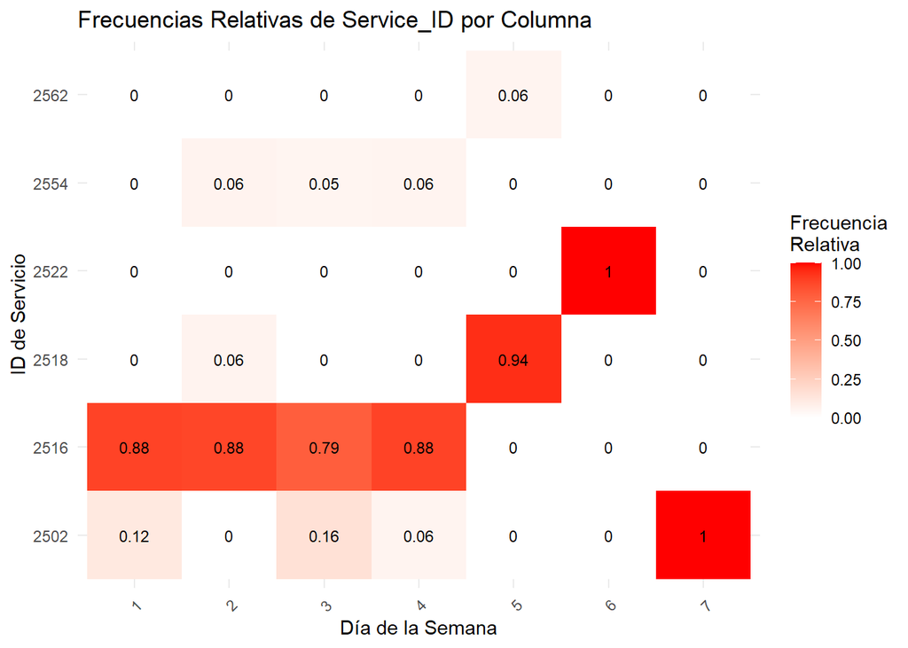

```r
# Convierte la tabla de frecuencias relativas en dataframe
df_for_heatmap <- as.data.frame(as.table(relative_frequencies))
names(df_for_heatmap) <- c("weekday", "service_id", "frequency")

# Asumiendo que ya tienes df_for_heatmap preparado como antes
ggplot(df_for_heatmap, aes(x = service_id, y = weekday, fill = frequency)) +
  geom_tile() +  # Crea las baldosas del mapa de calor
  geom_text(aes(label = round(frequency, 2)), color = "black", size = 3) +  # Añade texto
  scale_fill_gradient(low = "white", high = "red", name = "Frecuencia\nRelativa") +
  labs(title = "Frecuencias Relativas de Service_ID por Columna",
       x = "Día de la Semana", y = "ID de Servicio") +
  theme_minimal() +
  theme(axis.text.x = element_text(angle = 45, hjust = 1))
```

```r
gtfs$calendar %>%
  arrange(start_date)
```

```
## # A tibble: 8 × 10
##   service_id monday tuesday wednesday thursday friday saturday sunday start_date
##   <fct>       <int>   <int>     <int>    <int>  <int>    <int>  <int> <date>
## 1 100             0       0         0        0      0        1      0 2022-02-01
## 2 200             0       0         0        0      0        0      1 2022-02-01
## 3 2562            0       0         0        0      0        0      0 2024-02-09
## 4 2554            0       0         0        0      0        0      0 2024-02-13
## 5 2518            0       0         0        0      0        0      0 2024-03-15
## 6 2522            0       0         0        0      0        0      0 2024-03-23
## 7 2516            0       0         0        0      0        0      0 2024-05-02
## 8 2502            0       0         0        0      0        0      0 2024-12-25
## # ℹ 1 more variable: end_date <date>
```

```r
gtfs$.$dates_services <- gtfs$.$dates_services %>%
  mutate(weekday = wday(date, week_start = 1))

gtfs$.$dates_services %>%
  filter(weekday < 6) %>%
  arrange(date)
```

```
## # A tibble: 86 × 3
##    date       service_id weekday
##    <date>     <chr>        <dbl>
##  1 2024-02-09 2562             5
##  2 2024-02-12 2516             1
##  3 2024-02-13 2554             2
##  4 2024-02-14 2554             3
##  5 2024-02-15 2554             4
##  6 2024-02-16 2518             5
##  7 2024-02-19 2516             1
##  8 2024-02-20 2516             2
##  9 2024-02-21 2516             3
## 10 2024-02-22 2516             4
## # ℹ 76 more rows
```

Ahora voy a crear un dataframe con todas las fechas de 2024 y los service_id correspondientes a cada fecha

Primero se concatenan las tablas de fechas y servicios: dates_services y calendar_dates

```r
# quitar la columna exception_type
gtfs$calendar_dates <- gtfs$calendar_dates %>% select(-all_of(c("exception_type")))
```

```r
all_dates <- rbind(gtfs$calendar_dates, gtfs$.$dates_services)
```

```r
dates_24 <- all_dates %>%
  filter(year(date) == 2024) %>%
  arrange(date)

dates_24
```

```
## # A tibble: 404 × 3
##    service_id date       weekday
##    <chr>      <date>       <dbl>
##  1 100        2024-01-06       6
##  2 200        2024-01-07       7
##  3 100        2024-01-13       6
##  4 200        2024-01-14       7
##  5 100        2024-01-20       6
##  6 200        2024-01-21       7
##  7 100        2024-01-27       6
##  8 200        2024-01-28       7
##  9 100        2024-02-03       6
## 10 200        2024-02-04       7
## # ℹ 394 more rows
```

```r
gtfs$calendar %>%
  arrange(start_date)
```

```
## # A tibble: 8 × 10
##   service_id monday tuesday wednesday thursday friday saturday sunday start_date
##   <fct>       <int>   <int>     <int>    <int>  <int>    <int>  <int> <date>
## 1 100             0       0         0        0      0        1      0 2022-02-01
## 2 200             0       0         0        0      0        0      1 2022-02-01
## 3 2562            0       0         0        0      0        0      0 2024-02-09
## 4 2554            0       0         0        0      0        0      0 2024-02-13
## 5 2518            0       0         0        0      0        0      0 2024-03-15
## 6 2522            0       0         0        0      0        0      0 2024-03-23
## 7 2516            0       0         0        0      0        0      0 2024-05-02
## 8 2502            0       0         0        0      0        0      0 2024-12-25
## # ℹ 1 more variable: end_date <date>
```

```r
gtfs$calendar_dates %>%
  arrange(date)
```

```
## # A tibble: 150 × 3
##    service_id date       weekday
##    <chr>      <date>       <dbl>
##  1 2562       2024-02-09       5
##  2 2522       2024-02-10       6
##  3 2502       2024-02-11       7
##  4 2516       2024-02-12       1
##  5 2554       2024-02-13       2
##  6 2554       2024-02-14       3
##  7 2554       2024-02-15       4
##  8 2518       2024-02-16       5
##  9 2522       2024-02-17       6
## 10 2502       2024-02-18       7
## # ℹ 140 more rows
```

## Caracterización de las líneas de metro

Para cada service_id, para cada estación:

- Nº de metros / hora
- Nº de metros / día
- Nº de metros
- Intermediación de la estación (con grafo)
- Nº de metros / hora por línea
- Nº de metros / día por línea

Para cada línea:

- Nº de trasbordos posibles en cada línea. Nº de estaciones donde se pueden hacer trasbordo por línea

Crear un grafo con las estaciones y las líneas de metro

### Nº de metros

Vamos a usar el service_id más frecuente para hacer las pruebas.

```r
most_frequent_service_id <- gtfs$trips %>%
  group_by(service_id) %>%
  summarise(frequency = n()) %>%
  arrange(desc(frequency)) %>%
  head(1) %>%
  pull(service_id)

most_frequent_service_id
```

```
## [1] 2562
## Levels: 100 200 2502 2516 2518 2522 2554 2562
```

Recoger todos los trips con el service_id más frecuente

```r
trips_mf <- gtfs$trips %>%
  filter(service_id == most_frequent_service_id)

trips_mf
```

```
## # A tibble: 1,817 × 5
##    route_id    service_id trip_id trip_headsign  shape_id
##    <chr>       <fct>      <chr>   <chr>          <chr>
##  1 V10-190-197 2562       4174472 Natzaret       74
##  2 V10-197-190 2562       4174612 Alacant        73
##  3 V10-190-197 2562       4174473 Natzaret       74
##  4 V10-197-190 2562       4174613 Alacant        73
##  5 V10-190-197 2562       4174474 Natzaret       74
##  6 V10-197-190 2562       4174614 Alacant        73
##  7 V10-190-197 2562       4174475 Natzaret       74
##  8 V10-197-190 2562       4174615 Alacant        73
##  9 V10-190-197 2562       4174476 Natzaret       74
## 10 V1-20-36    2562       4173390 Seminari - CEU 48
## # ℹ 1,807 more rows
```

Unir las tablas de rutas, trips, stop_times y stops

```r
trips_stops_details <- trips_mf %>%
  inner_join(gtfs$routes, by = "route_id") %>%
  inner_join(gtfs$stop_times, by = "trip_id") %>%
  inner_join(gtfs$stops, by = "stop_id")

trips_stops_details
```

```
## # A tibble: 31,587 × 21
##    route_id service_id trip_id trip_headsign shape_id agency_id route_short_name
##    <chr>    <fct>      <chr>   <chr>         <chr>    <chr>     <chr>
##  1 V10-190… 2562       4174472 Natzaret      74       1         10
##  2 V10-190… 2562       4174472 Natzaret      74       1         10
##  3 V10-190… 2562       4174472 Natzaret      74       1         10
##  4 V10-190… 2562       4174472 Natzaret      74       1         10
##  5 V10-190… 2562       4174472 Natzaret      74       1         10
##  6 V10-190… 2562       4174472 Natzaret      74       1         10
##  7 V10-190… 2562       4174472 Natzaret      74       1         10
##  8 V10-190… 2562       4174472 Natzaret      74       1         10
##  9 V10-197… 2562       4174612 Alacant       73       1         10
## 10 V10-197… 2562       4174612 Alacant       73       1         10
## # ℹ 31,577 more rows
## # ℹ 14 more variables: route_long_name <chr>, route_type <int>,
## #   route_color <chr>, route_text_color <chr>, arrival_time <time>,
## #   departure_time <time>, stop_id <chr>, stop_sequence <int>, timepoint <int>,
## #   time_of_day <chr>, stop_name <chr>, stop_lat <dbl>, stop_lon <dbl>,
## #   zone_id <chr>
```

Número de metros por hora por estación.

Quiero una tabla que tenga por cada fila:

stop_id, stop_name, numero de metros por hora con una columna para cada hora

```r
metros_por_hora <- trips_stops_details %>%
  group_by(stop_id, stop_name, hour = hour(arrival_time)) %>%
  summarise(metros = n())
metros_por_hora
```

```
## # A tibble: 3,106 × 4
## # Groups:   stop_id, stop_name [142]
##    stop_id stop_name    hour metros
##    <chr>   <chr>       <int>  <int>
##  1 1       Rafelbunyol     0      1
##  2 1       Rafelbunyol     1      2
##  3 1       Rafelbunyol     3      1
##  4 1       Rafelbunyol     5      4
##  5 1       Rafelbunyol     6      4
##  6 1       Rafelbunyol     7      8
##  7 1       Rafelbunyol     8      8
##  8 1       Rafelbunyol     9      8
##  9 1       Rafelbunyol    10      8
## 10 1       Rafelbunyol    11      8
## # ℹ 3,096 more rows
```

Quiero trasponer las columnas hour y metros para tener una columna por cada hora

```r
library(tidyr)
metros_por_hora_t <- metros_por_hora %>%
  pivot_wider(names_from = hour, values_from = metros, values_fill = 0)

metros_por_hora_t
```

```
## # A tibble: 142 × 26
## # Groups:   stop_id, stop_name [142]
##    stop_id stop_name   `0`   `1`   `3`   `5`   `6`   `7`   `8`   `9`  `10`  `11`
##    <chr>   <chr>     <int> <int> <int> <int> <int> <int> <int> <int> <int> <int>
##  1 1       Rafelbun…     1     2     1     4     4     8     8     8     8     8
##  2 10      Alboraia…     3     4     0     3     7    15    16    16    16    16
##  3 100     Palau de…     3     3     0     5     8    13    12    12    12    12
##  4 101     La Granja     3     3     0     4    14    18    18    18    18    18
##  5 102     Sant Joan     3     3     0     4    14    18    18    18    18    18
##  6 103     Campus        3     3     0     4    14    18    18    18    18    18
##  7 104     Vicent A…     3     3     0     5    13    18    18    18    18    18
##  8 105     À Punt        0     0     0     3     9    12    12    12    12    12
##  9 107     Bétera        1     2     1     1     5     5     5     4     2     4
## 10 108     El Clot       1     2     1     1     6     8     6     4     4     4
## # ℹ 132 more rows
## # ℹ 14 more variables: `12` <int>, `13` <int>, `14` <int>, `15` <int>,
## #   `16` <int>, `17` <int>, `18` <int>, `19` <int>, `20` <int>, `21` <int>,
## #   `22` <int>, `23` <int>, `2` <int>, `4` <int>
```

Número de metros por día por estación, sumando los metros por hora

```r
metros_por_dia <- metros_por_hora %>%
  group_by(stop_id, stop_name) %>%
  summarise(metros = sum(metros))
metros_por_dia
```

```
## # A tibble: 142 × 3
## # Groups:   stop_id [142]
##    stop_id stop_name              metros
##    <chr>   <chr>                   <int>
##  1 1       Rafelbunyol               137
##  2 10      Alboraia Palmaret         264
##  3 100     Palau de Congressos       218
##  4 101     La Granja                 312
##  5 102     Sant Joan                 312
##  6 103     Campus                    312
##  7 104     Vicent Andrés Estellés    312
##  8 105     À Punt                    201
##  9 107     Bétera                     77
## 10 108     El Clot                    87
## # ℹ 132 more rows
```

Número de líneas que pasan por cada estación, con una columna que contiene una lista con las líneas y otra con el número de líneas

```r
lines_per_station <- trips_stops_details %>%
  group_by(stop_id, stop_name) %>%
  summarise(lines = list(unique(route_short_name)), n_lines = length(unique(route_short_name)))
lines_per_station
```

```
## # A tibble: 142 × 4
## # Groups:   stop_id [142]
##    stop_id stop_name              lines     n_lines
##    <chr>   <chr>                  <list>      <int>
##  1 1       Rafelbunyol            <chr [1]>       1
##  2 10      Alboraia Palmaret      <chr [2]>       2
##  3 100     Palau de Congressos    <chr [1]>       1
##  4 101     La Granja              <chr [1]>       1
##  5 102     Sant Joan              <chr [1]>       1
##  6 103     Campus                 <chr [1]>       1
##  7 104     Vicent Andrés Estellés <chr [1]>       1
##  8 105     À Punt                 <chr [1]>       1
##  9 107     Bétera                 <chr [1]>       1
## 10 108     El Clot                <chr [1]>       1
## # ℹ 132 more rows
```

Ahora se buscará una tabla con los metros por hora de cada línea y cada estación. Se agrupará por `route_short_name`, `stop_id` y `hour` y se sumarán los metros.

```r
metros_por_hora_linea <- trips_stops_details %>%
  group_by(route_short_name, stop_id, stop_name, hour = hour(arrival_time)) %>%
  summarise(metros = n())
```

```
## You can override using the `.groups` argument.
```

```r
metros_por_hora_linea
```

```
## # A tibble: 4,844 × 5
## # Groups:   route_short_name, stop_id, stop_name [233]
##    route_short_name stop_id stop_name  hour metros
##    <chr>            <chr>   <chr>     <int>  <int>
##  1 1                107     Bétera        0      1
##  2 1                107     Bétera        1      2
##  3 1                107     Bétera        2      1
##  4 1                107     Bétera        3      1
##  5 1                107     Bétera        5      1
##  6 1                107     Bétera        6      5
##  7 1                107     Bétera        7      5
##  8 1                107     Bétera        8      5
##  9 1                107     Bétera        9      4
## 10 1                107     Bétera       10      2
## # ℹ 4,834 more rows
```

Se traspondrá la tabla para tener una columna por cada hora

```r
metros_por_hora_linea_t <- metros_por_hora_linea %>%
  pivot_wider(names_from = hour, values_from = metros, values_fill = 0)

metros_por_hora_linea_t
```

```
## # A tibble: 233 × 27
## # Groups:   route_short_name, stop_id, stop_name [233]
##    route_short_name stop_id stop_name    `0`   `1`   `2`   `3`   `5`   `6`   `7`
##    <chr>            <chr>   <chr>      <int> <int> <int> <int> <int> <int> <int>
##  1 1                107     Bétera         1     2     1     1     1     5     5
##  2 1                17      Àngel Gui…     4     2     4     0     6     8    10
##  3 1                25      Jesús          4     2     4     0     6     9     9
##  4 1                26      Patraix        4     2     4     0     6     9     9
##  5 1                27      Safranar       3     3     3     0     6     9     9
##  6 1                28      Sant Isid…     3     3     3     0     6     9     9
##  7 1                30      València …     3     3     3     0     7     9     9
##  8 1                31      Paiporta       3     3     3     0     3     8     9
##  9 1                32      Picanya        3     3     3     0     3     8    10
## 10 1                33      Torrent        2     4     2     1     4     8    10
## # ℹ 223 more rows
## # ℹ 17 more variables: `8` <int>, `9` <int>, `10` <int>, `11` <int>,
## #   `12` <int>, `13` <int>, `14` <int>, `15` <int>, `16` <int>, `17` <int>,
## #   `18` <int>, `19` <int>, `20` <int>, `21` <int>, `22` <int>, `23` <int>,
## #   `4` <int>
```

Se calculará el número de metros por día por línea y estación

```r
metros_por_dia_linea <- metros_por_hora_linea %>%
  group_by(route_short_name, stop_id, stop_name) %>%
  summarise(metros = sum(metros))
metros_por_dia_linea
```

```
## # A tibble: 233 × 4
## # Groups:   route_short_name, stop_id [233]
##    route_short_name stop_id stop_name     metros
##    <chr>            <chr>   <chr>          <int>
##  1 1                107     Bétera            77
##  2 1                17      Àngel Guimerà    163
##  3 1                25      Jesús            163
##  4 1                26      Patraix          163
##  5 1                27      Safranar         163
##  6 1                28      Sant Isidre      163
##  7 1                30      València Sud     167
##  8 1                31      Paiporta         154
##  9 1                32      Picanya          154
## 10 1                33      Torrent          154
## # ℹ 223 more rows
```

## Grafo de estaciones y líneas de metro

Se creará un grafo con las estaciones y las líneas de metro.

Primero se creará un dataframe con las estaciones y las líneas de metro que pasan por cada estación

```r
lines_per_station <- trips_stops_details %>%
  group_by(stop_id, stop_name) %>%
  summarise(lines = list(unique(route_short_name)), n_lines = length(unique(route_short_name)))
lines_per_station
```

```
## # A tibble: 142 × 4
## # Groups:   stop_id [142]
##    stop_id stop_name              lines     n_lines
##    <chr>   <chr>                  <list>      <int>
##  1 1       Rafelbunyol            <chr [1]>       1
##  2 10      Alboraia Palmaret      <chr [2]>       2
##  3 100     Palau de Congressos    <chr [1]>       1
##  4 101     La Granja              <chr [1]>       1
##  5 102     Sant Joan              <chr [1]>       1
##  6 103     Campus                 <chr [1]>       1
##  7 104     Vicent Andrés Estellés <chr [1]>       1
##  8 105     À Punt                 <chr [1]>       1
##  9 107     Bétera                 <chr [1]>       1
## 10 108     El Clot                <chr [1]>       1
## # ℹ 132 more rows
```

```r
head(lines_per_station$lines)
```

```
## [[1]]
## [1] "3"
##
## [[2]]
## [1] "3" "9"
##
## [[3]]
## [1] "4"
##
## [[4]]
## [1] "4"
##
## [[5]]
## [1] "4"
##
## [[6]]
## [1] "4"
```

Para crear el grafo, se necesita una lista de nodos y de aristas. La lista de nodos será la lista de estaciones y la lista de aristas se obtendrá de las líneas de metro, uniendo dos a dos las estaciones que pertenecen a la misma línea y que están en la misma secuencia de paradas. El peso de las aristas será el tiempo que se tarda en llegar desde una estación a otra.

Primero se creará la lista de nodos

```r
nodes <- lines_per_station %>%
  select(stop_id, stop_name) %>%
  rename(id = stop_id, name = stop_name)

nodes
```

```
## # A tibble: 142 × 2
## # Groups:   id [142]
##    id    name
##    <chr> <chr>
##  1 1     Rafelbunyol
##  2 10    Alboraia Palmaret
##  3 100   Palau de Congressos
##  4 101   La Granja
##  5 102   Sant Joan
##  6 103   Campus
##  7 104   Vicent Andrés Estellés
##  8 105   À Punt
##  9 107   Bétera
## 10 108   El Clot
## # ℹ 132 more rows
```

Ahora voy a ver cómo se puede hacer para unir dos a dos las estaciones que pertenecen a la misma línea y que están en la misma secuencia de paradas.

Primero se unirán las tablas de paradas y de rutas

```r
stops_routes <- trips_stops_details %>%
  select(stop_id, stop_name, route_id, route_long_name, route_short_name) %>%
  distinct()

stops_routes
```

```
## # A tibble: 1,657 × 5
##    stop_id stop_name                   route_id route_long_name route_short_name
##    <chr>   <chr>                       <chr>    <chr>           <chr>
##  1 190     Alacant                     V10-190… 10 - Alacant -… 10
##  2 191     Russafa                     V10-190… 10 - Alacant -… 10
##  3 192     Amado Granell - Montolivet  V10-190… 10 - Alacant -… 10
##  4 193     Quatre Carreres             V10-190… 10 - Alacant -… 10
##  5 194     Ciutat Arts i Ciències - J… V10-190… 10 - Alacant -… 10
##  6 195     Oceanogràfic                V10-190… 10 - Alacant -… 10
##  7 196     Moreres                     V10-190… 10 - Alacant -… 10
##  8 197     Natzaret                    V10-190… 10 - Alacant -… 10
##  9 197     Natzaret                    V10-197… 10 - Natzaret … 10
## 10 196     Moreres                     V10-197… 10 - Natzaret … 10
## # ℹ 1,647 more rows
```

Ahora quiero una lista de todas las paradas que contiene cada ruta, ordenadas por la secuencia de paradas

```r
stops_routes_ordered <- stops_routes %>%
  group_by(route_id, route_short_name, route_long_name) %>%

  arrange(route_id, stop_id) %>%
  summarise(stops = list(stop_id), n_stops = n())
stops_routes_ordered
```

```
## # A tibble: 92 × 5
## # Groups:   route_id, route_short_name [92]
##    route_id route_short_name route_long_name                stops      n_stops
##    <chr>    <chr>            <chr>                          <list>       <int>
##  1 V1-1-29  1                1 - Castelló - Empalme         <chr [30]>      30
##  2 V1-1-36  1                1 - Castelló - Seminari - CEU  <chr [37]>      37
##  3 V1-1-39  1                1 - Castelló - Bétera          <chr [40]>      40
##  4 V1-11-1  1                1 - Espioca - Castelló         <chr [37]>      37
##  5 V1-13-20 1                1 - Picassent - València Sud   <chr [8]>        8
##  6 V1-13-29 1                1 - Picassent - Empalme        <chr [18]>      18
##  7 V1-13-36 1                1 - Picassent - Seminari - CEU <chr [25]>      25
##  8 V1-13-39 1                1 - Picassent - Bétera         <chr [28]>      28
##  9 V1-17-36 1                1 - Torrent - Seminari - CEU   <chr [21]>      21
## 10 V1-17-39 1                1 - Torrent - Bétera           <chr [24]>      24
## # ℹ 82 more rows
```

Comprobar qué rutas son subconjuntos de otras

```r
is_subset <- rep(FALSE, nrow(stops_routes_ordered))

for (i in 1:nrow(stops_routes_ordered)) {
  for (j in 1:nrow(stops_routes_ordered)) {
    if (i != j) {
      r1 <- stops_routes_ordered$stops[[i]]
      r2 <- stops_routes_ordered$stops[[j]]
      if (all(r1 %in% r2) && length(r1) < length(r2)) {
        is_subset[i] <- TRUE
      }
    }
  }
}
```

```r
stops_routes_ordered$is_subset <- is_subset
```

```r
routes_non_subset <- stops_routes_ordered %>%
  filter(is_subset == FALSE)

routes_non_subset
```

```
## # A tibble: 25 × 6
## # Groups:   route_id, route_short_name [25]
##    route_id    route_short_name route_long_name          stops n_stops is_subset
##    <chr>       <chr>            <chr>                    <lis>   <int> <lgl>
##  1 V1-1-39     1                1 - Castelló - Bétera    <chr>      40 FALSE
##  2 V1-39-1     1                1 - Bétera - Castelló    <chr>      40 FALSE
##  3 V1-39-107   1                1 - Bétera - Torrent Av… <chr>      25 FALSE
##  4 V10-190-197 10               10 - Alacant - Natzaret  <chr>       8 FALSE
##  5 V10-197-190 10               10 - Natzaret - Alacant  <chr>       8 FALSE
##  6 V2-107-54   2                2 - Torrent Avinguda - … <chr>      33 FALSE
##  7 V2-54-107   2                2 - Llíria - Torrent Av… <chr>      33 FALSE
##  8 V3-182-64   3                3 - Aeroport - Rafelbun… <chr>      27 FALSE
##  9 V3-64-182   3                3 - Rafelbunyol - Aerop… <chr>      27 FALSE
## 10 V4-114-98   4                4 - Mas del Rosari - Dr… <chr>      30 FALSE
## # ℹ 15 more rows
```

Es el momento de obtener la estación de salida de esa ruta y la estación de llegada. Se crearán dos columnas en la tabla stops_routes_ordered con la estación de salida y la estación de llegada, que se obtienen a partir de dividir la columna `route_long_name` con ” - “.

```r
first <- routes_non_subset$stops[[1]][1]
first
```

```
## [1] "107"
```

```r
gtfs$stops %>%
  filter(stop_id == first)
```

```
## # A tibble: 1 × 5
##   stop_id stop_name stop_lat stop_lon zone_id
##   <chr>   <chr>        <dbl>    <dbl> <chr>
## 1 107     Bétera        39.6   -0.458 B
```

```r
routes_non_subset <- routes_non_subset %>%
  mutate(start_station = sapply(strsplit(route_long_name, " - "), function(x) x[2]),
         end_station = sapply(strsplit(route_long_name, " - "), function(x) x[3]))

routes_non_subset
```

```
## # A tibble: 25 × 8
## # Groups:   route_id, route_short_name [25]
##    route_id    route_short_name route_long_name          stops n_stops is_subset
##    <chr>       <chr>            <chr>                    <lis>   <int> <lgl>
##  1 V1-1-39     1                1 - Castelló - Bétera    <chr>      40 FALSE
##  2 V1-39-1     1                1 - Bétera - Castelló    <chr>      40 FALSE
##  3 V1-39-107   1                1 - Bétera - Torrent Av… <chr>      25 FALSE
##  4 V10-190-197 10               10 - Alacant - Natzaret  <chr>       8 FALSE
##  5 V10-197-190 10               10 - Natzaret - Alacant  <chr>       8 FALSE
##  6 V2-107-54   2                2 - Torrent Avinguda - … <chr>      33 FALSE
##  7 V2-54-107   2                2 - Llíria - Torrent Av… <chr>      33 FALSE
##  8 V3-182-64   3                3 - Aeroport - Rafelbun… <chr>      27 FALSE
##  9 V3-64-182   3                3 - Rafelbunyol - Aerop… <chr>      27 FALSE
## 10 V4-114-98   4                4 - Mas del Rosari - Dr… <chr>      30 FALSE
## # ℹ 15 more rows
## # ℹ 2 more variables: start_station <chr>, end_station <chr>
```

```r
first <- routes_non_subset$start_station[1]
first
```

```
## [1] "Castelló"
```

```r
gtfs$stops %>%
  filter(stop_name == first)
```

```
## # A tibble: 1 × 5
##   stop_id stop_name stop_lat stop_lon zone_id
##   <chr>   <chr>        <dbl>    <dbl> <chr>
## 1 35      Castelló      39.1   -0.516 B
```

Ahora voy a conseguir los trips que pasan por las rutas que no son subsets.

```r
trips_routes_non_subset <- gtfs$trips %>%
  inner_join(routes_non_subset, by = "route_id") %>%
  select(route_id, service_id, trip_id, route_short_name, route_long_name, start_station, end_station, stops, n_stops)

# drop duplicated rows with the same route_id

trips_routes_non_subset <- trips_routes_non_subset %>%
  distinct(route_id, .keep_all = TRUE)

trips_routes_non_subset
```

```
## # A tibble: 25 × 9
##    route_id    service_id trip_id route_short_name route_long_name start_station
##    <chr>       <fct>      <chr>   <chr>            <chr>           <chr>
##  1 V10-190-197 2502       4118993 10               10 - Alacant -… Alacant
##  2 V10-197-190 2502       4119082 10               10 - Natzaret … Natzaret
##  3 V1-39-1     2502       4118020 1                1 - Bétera - C… Bétera
##  4 V1-1-39     2502       4118304 1                1 - Castelló -… Castelló
##  5 V2-107-54   2502       4118348 2                2 - Torrent Av… Torrent Avin…
##  6 V2-54-107   2502       4118070 2                2 - Llíria - T… Llíria
##  7 V3-182-64   2502       4118395 3                3 - Aeroport -… Aeroport
##  8 V3-64-182   2502       4118119 3                3 - Rafelbunyo… Rafelbunyol
##  9 V4-98-114   2502       4118578 4                4 - Dr. Lluch … Dr. Lluch
## 10 V4-114-98   2502       4118786 4                4 - Mas del Ro… Mas del Rosa…
## # ℹ 15 more rows
## # ℹ 3 more variables: end_station <chr>, stops <list>, n_stops <int>
```

```r
trip_ejemplo <- trips_routes_non_subset$trip_id[1]



trip_ejemplo_completo <- gtfs$stop_times %>%
  filter(trip_id == trip_ejemplo) %>%
  inner_join(gtfs$stops, by = "stop_id") %>%
  select(stop_id, stop_name, arrival_time, departure_time, stop_sequence) %>%
  arrange(stop_sequence)

trip_ejemplo_completo
```

```
## # A tibble: 8 × 5
##   stop_id stop_name                    arrival_time departure_time stop_sequence
##   <chr>   <chr>                        <time>       <time>                 <int>
## 1 190     Alacant                      06:50        06:50                      1
## 2 191     Russafa                      06:54        06:54                      2
## 3 192     Amado Granell - Montolivet   06:56        06:56                      3
## 4 193     Quatre Carreres              06:58        06:58                      4
## 5 194     Ciutat Arts i Ciències - Ju… 07:01        07:01                      5
## 6 195     Oceanogràfic                 07:03        07:03                      6
## 7 196     Moreres                      07:05        07:05                      7
## 8 197     Natzaret                     07:06        07:06                      8
```

Ahora quiero crear pares de paradas consecutivas en cada trip, con sus correspondientes horas de llegada.

```r
pares_paradas <- trip_ejemplo_completo %>%
  select(stop_id, stop_name, arrival_time) %>%
  slice(1:(nrow(.) - 1)) %>%
  rename(stop_id_1 = stop_id, stop_name_1 = stop_name, arrival_time_1 = arrival_time) %>%
  bind_cols(trip_ejemplo_completo %>%
              select(stop_id, stop_name, arrival_time) %>%
              slice(2:nrow(.)) %>%
              rename(stop_id_2 = stop_id, stop_name_2 = stop_name, arrival_time_2 = arrival_time))

# crear una columna con la duración del trayecto

pares_paradas <- pares_paradas %>%
  mutate(duration = as.numeric(difftime(arrival_time_2, arrival_time_1, units = "mins")))

pares_paradas
```

```
## # A tibble: 7 × 7
##   stop_id_1 stop_name_1      arrival_time_1 stop_id_2 stop_name_2 arrival_time_2
##   <chr>     <chr>            <time>         <chr>     <chr>       <time>
## 1 190       Alacant          06:50          191       Russafa     06:54
## 2 191       Russafa          06:54          192       Amado Gran… 06:56
## 3 192       Amado Granell -… 06:56          193       Quatre Car… 06:58
## 4 193       Quatre Carreres  06:58          194       Ciutat Art… 07:01
## 5 194       Ciutat Arts i C… 07:01          195       Oceanogràf… 07:03
## 6 195       Oceanogràfic     07:03          196       Moreres     07:05
## 7 196       Moreres          07:05          197       Natzaret    07:06
## # ℹ 1 more variable: duration <dbl>
```

Ahora hay que realizar este proceso para todos los trips que se han conseguido antes.

```r
for (i in 1:nrow(trips_routes_non_subset)) {
  trip_id <- trips_routes_non_subset$trip_id[i]
  print(trip_id)

  trip_completo <- gtfs$stop_times %>%
    filter(trip_id == trip_id)

  print(trip_completo)
  break
}
```

```
## [1] "4118993"
## # A tibble: 208,261 × 7
##    trip_id arrival_time departure_time stop_id stop_sequence timepoint
##    <chr>   <time>       <time>         <chr>           <int>     <int>
##  1 2965738 04:44        04:44          86                  0         1
##  2 2965738 04:45        04:45          87                  1         1
##  3 2965738 04:46        04:46          88                  2         1
##  4 2965738 04:47        04:47          89                  3         1
##  5 2965738 04:49        04:49          90                  4         1
##  6 2965738 04:51        04:51          12                  5         1
##  7 2965738 04:53        04:53          91                  6         1
##  8 2965738 04:57        04:57          92                  7         1
##  9 2965738 05:00        05:00          93                  8         1
## 10 2965738 05:02        05:02          94                  9         1
## # ℹ 208,251 more rows
## # ℹ 1 more variable: time_of_day <chr>
```

```r
all_stops_pairs <- list()

length(all_stops_pairs)
```

```
## [1] 0
```

```r
for (i in 1:nrow(trips_routes_non_subset)) {
  trip_i <- trips_routes_non_subset$trip_id[i]

  trip_completo <- gtfs$stop_times %>%
    filter(trip_id == trip_i) %>%
    inner_join(gtfs$stops, by = "stop_id") %>%
    select(stop_id, stop_name, arrival_time, departure_time, stop_sequence) %>%
    arrange(stop_sequence)

  pares_paradas <- trip_completo %>%
    select(stop_id, stop_name, arrival_time) %>%
    slice(1:(nrow(.) - 1)) %>%
    rename(stop_id_1 = stop_id, stop_name_1 = stop_name, arrival_time_1 = arrival_time) %>%
    bind_cols(trip_completo %>%
                select(stop_id, stop_name, arrival_time) %>%
                slice(2:nrow(.)) %>%
                rename(stop_id_2 = stop_id, stop_name_2 = stop_name, arrival_time_2 = arrival_time))

# crear una columna con la duración del trayecto

  pares_paradas <- pares_paradas %>%
    mutate(duration = as.numeric(difftime(arrival_time_2, arrival_time_1, units = "mins")))

  all_stops_pairs[[i]] <- pares_paradas
}

complete_trips <- bind_rows(all_stops_pairs)
```

```r
# delete duplicated rows
complete_trips <- complete_trips %>%
  distinct(stop_id_1, stop_id_2, .keep_all = TRUE)
```

A los vértices se les puede añadir atributos con su latitud y longitud. Para eso hay que unir la tabla complete_trips con gtfs$stops.

```r
complete_trips <- complete_trips %>%
  inner_join(gtfs$stops, by = c("stop_id_1" = "stop_id")) %>%
  select(-stop_name) %>%
  rename(lat_1 = stop_lat, lon_1 = stop_lon) %>%
  inner_join(gtfs$stops, by = c("stop_id_2" = "stop_id")) %>%
  select(-stop_name) %>%
  rename(lat_2 = stop_lat, lon_2 = stop_lon)

complete_trips
```

```
## # A tibble: 282 × 13
##    stop_id_1 stop_name_1     arrival_time_1 stop_id_2 stop_name_2 arrival_time_2
##    <chr>     <chr>           <time>         <chr>     <chr>       <time>
##  1 190       Alacant         06:50          191       Russafa     06:54
##  2 191       Russafa         06:54          192       Amado Gran… 06:56
##  3 192       Amado Granell … 06:56          193       Quatre Car… 06:58
##  4 193       Quatre Carreres 06:58          194       Ciutat Art… 07:01
##  5 194       Ciutat Arts i … 07:01          195       Oceanogràf… 07:03
##  6 195       Oceanogràfic    07:03          196       Moreres     07:05
##  7 196       Moreres         07:05          197       Natzaret    07:06
##  8 197       Natzaret        07:10          196       Moreres     07:11
##  9 196       Moreres         07:11          195       Oceanogràf… 07:13
## 10 195       Oceanogràfic    07:13          194       Ciutat Art… 07:15
## # ℹ 272 more rows
## # ℹ 7 more variables: duration <dbl>, lat_1 <dbl>, lon_1 <dbl>,
## #   zone_id.x <chr>, lat_2 <dbl>, lon_2 <dbl>, zone_id.y <chr>
```

```r
node_pairs <- complete_trips %>%
  select(stop_id_1, stop_id_2)
```

```r
# drop duplicates from complete_trips
distinct_nodes <- complete_trips %>%
  distinct(stop_id_1, .keep_all = TRUE)
distinct_nodes
```

```
## # A tibble: 142 × 13
##    stop_id_1 stop_name_1     arrival_time_1 stop_id_2 stop_name_2 arrival_time_2
##    <chr>     <chr>           <time>         <chr>     <chr>       <time>
##  1 190       Alacant         06:50          191       Russafa     06:54
##  2 191       Russafa         06:54          192       Amado Gran… 06:56
##  3 192       Amado Granell … 06:56          193       Quatre Car… 06:58
##  4 193       Quatre Carreres 06:58          194       Ciutat Art… 07:01
##  5 194       Ciutat Arts i … 07:01          195       Oceanogràf… 07:03
##  6 195       Oceanogràfic    07:03          196       Moreres     07:05
##  7 196       Moreres         07:05          197       Natzaret    07:06
##  8 197       Natzaret        07:10          196       Moreres     07:11
##  9 107       Bétera          07:36          80        Horta Vella 07:38
## 10 80        Horta Vella     07:38          79        Masies      07:42
## # ℹ 132 more rows
## # ℹ 7 more variables: duration <dbl>, lat_1 <dbl>, lon_1 <dbl>,
## #   zone_id.x <chr>, lat_2 <dbl>, lon_2 <dbl>, zone_id.y <chr>
```

```r
library(igraph)
g <- graph_from_data_frame(node_pairs, directed = TRUE)

E(g)$weight <- complete_trips$duration
V(g)$stop_name <- distinct_nodes$stop_name_1
V(g)$lat <- distinct_nodes$lat_1
V(g)$lon <- distinct_nodes$lon_1
V(g)$zone <- distinct_nodes$zone_id.x
```

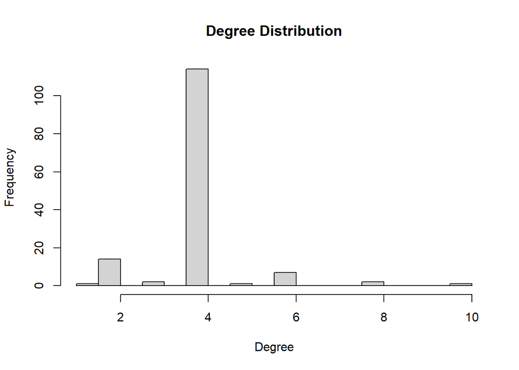

```r
# study degree distribution
degree_distribution <- degree(g)

hist(degree_distribution, breaks = 20, main = "Degree Distribution", xlab = "Degree")
```

```r
V(g)[neighbors(g, which.max(degree_distribution))]$stop_name
```

```
## [1] "Burjassot"           "Beniferri"           "Cantereria"
## [4] "Palau de Congressos" "La Granja"
```

```r
# shortet path from benimaclet to sant isidre
s1 <- V(g)[stop_name == "Sant Isidre"]
s2 <- V(g)[stop_name == "Àngel Guimerà"]

shortest_path <- shortest_paths(g, from = s2, to = s1)

# get the path
shortest_path$vpath[[1]]$stop_name
```

```
## [1] "Àngel Guimerà" "Pl. Espanya"   "Jesús"         "Patraix"
## [5] "Safranar"      "Sant Isidre"
```

Ahora falta incluir qué líneas de metro pasan por cada estación.

```r
lines_per_station <- trips_stops_details %>%
  group_by(stop_id, stop_name) %>%
  summarise(lines = list(unique(route_short_name)), n_lines = length(unique(route_short_name)), .groups = "drop")

# sort the same as the graph
distinct_nodes <- distinct_nodes %>%
  inner_join(lines_per_station, by = c("stop_id_1" = "stop_id")) %>%
  select(-stop_name) %>%
  rename(stop_name = stop_name_1)

distinct_nodes
```

```
## # A tibble: 142 × 15
##    stop_id_1 stop_name       arrival_time_1 stop_id_2 stop_name_2 arrival_time_2
##    <chr>     <chr>           <time>         <chr>     <chr>       <time>
##  1 190       Alacant         06:50          191       Russafa     06:54
##  2 191       Russafa         06:54          192       Amado Gran… 06:56
##  3 192       Amado Granell … 06:56          193       Quatre Car… 06:58
##  4 193       Quatre Carreres 06:58          194       Ciutat Art… 07:01
##  5 194       Ciutat Arts i … 07:01          195       Oceanogràf… 07:03
##  6 195       Oceanogràfic    07:03          196       Moreres     07:05
##  7 196       Moreres         07:05          197       Natzaret    07:06
##  8 197       Natzaret        07:10          196       Moreres     07:11
##  9 107       Bétera          07:36          80        Horta Vella 07:38
## 10 80        Horta Vella     07:38          79        Masies      07:42
## # ℹ 132 more rows
## # ℹ 9 more variables: duration <dbl>, lat_1 <dbl>, lon_1 <dbl>,
## #   zone_id.x <chr>, lat_2 <dbl>, lon_2 <dbl>, zone_id.y <chr>, lines <list>,
## #   n_lines <int>
```

```r
V(g)$lines <- distinct_nodes$lines
```

Ahora falta poner en qué líneas está cada par de nodos (ruta entre uno y otro). Para esto, se usará la intersección entre las líneas que están en un nodo y las del siguiente

```r
s1$stop_name
```

```
## [1] "Sant Isidre"
```

```r
s2$stop_name
```

```
## [1] "Àngel Guimerà"
```

```r
s1$lines[[1]]
```

[output not shown]

```r
intersect(s1$lines[[1]], s2$lines[[1]])
```

[output not shown]

```r
edge_s1s2 <- E(g)[from = s1, to = s2]
list(intersect(s1$lines[[1]], s2$lines[[1]]))
```

```
## [[1]]
## [1] "1" "2"
```

```r
head_of(g, E(g)[1])
```

```
## + 1/142 vertex, named, from 0b1fa4e:
## [1] 191
```

```r
tail_of(g, E(g)[1])
```

```
## + 1/142 vertex, named, from 0b1fa4e:
## [1] 190
```

```r
E(g)$lines <- NA


for (i in 1:length(E(g))) {
  edge <- E(g)[i]
  from <- head_of(g, edge)
  to <- tail_of(g, edge)

  lines_from <- V(g)[from]$lines[[1]]
  lines_to <- V(g)[to]$lines[[1]]

  E(g)$lines[i] <- list(intersect(lines_from, lines_to))
}
```

```r
# get the subgraph of line 4 if any line 4 in station$lines[[i]]
"4" %in% V(g)$lines[[23]]
```

```
## [1] FALSE
```

```r
line_4 <- rep(NA, length(V(g)))

for (i in 1:length(V(g))) {
  line_4[i] <- "4" %in% V(g)$lines[[i]]
}
```

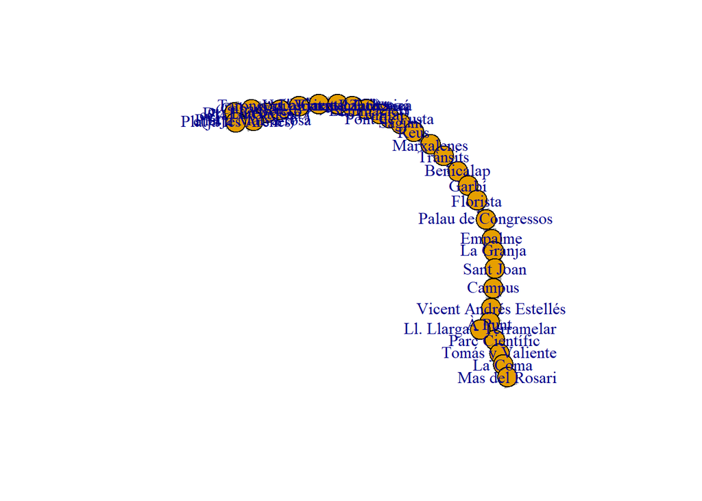

```r
line_4 <- induced_subgraph(g, line_4)

plot(line_4, vertex.label = V(line_4)$stop_name, edge.label = E(line_4)$lines)
```

```r
V(line_4)[1]$stop_name
```

```
## [1] "Empalme"
```